# Latihan Analisis Biplot

DIANI RARAS PUSPITA

2025-11-19

## Biplot untuk data Bank (menggunakan nilai dari gambar)

```r
# 1) Buat data frame dari tabel (baris = bank, kolom = atribut)
data_bank <- data.frame(
  Bank = c("BR","BC","BMD","NI","BN","BDN","BMG","BPM"),
  Petugas  = c(4.31, 7.64, 8.94, 7.21, 5.74, 4.03, 6.96, 4.99),
  Produk   = c(3.89, 7.40, 7.12, 4.20, 6.34, 3.55, 3.11, 5.00),
  Kantor   = c(5.67, 8.58, 8.61, 6.39, 8.22, 4.26, 4.09, 6.31),
  ATM      = c(5.89, 8.15, 6.89, 3.58, 6.31, 4.09, 3.23, 6.17),
  Hadiah   = c(5.12, 6.74, 7.45, 4.23, 7.05, 6.90, 3.21, 5.89),
  Keamanan = c(7.11, 8.23, 8.35, 6.87, 7.65, 6.80, 6.12, 7.62),
  Lokasi   = c(4.12, 6.77, 7.89, 4.34, 6.89, 3.44, 2.86, 5.36),
  stringsAsFactors = FALSE
)
```

```r
# lihat data
print(data_bank)
```

```
##   Bank Petugas Produk Kantor  ATM Hadiah Keamanan Lokasi
## 1   BR    4.31   3.89   5.67 5.89   5.12     7.11   4.12
## 2   BC    7.64   7.40   8.58 8.15   6.74     8.23   6.77
## 3  BMD    8.94   7.12   8.61 6.89   7.45     8.35   7.89
## 4   NI    7.21   4.20   6.39 3.58   4.23     6.87   4.34
## 5   BN    5.74   6.34   8.22 6.31   7.05     7.65   6.89
## 6  BDN    4.03   3.55   4.26 4.09   6.90     6.80   3.44
## 7  BMG    6.96   3.11   4.09 3.23   3.21     6.12   2.86
## 8  BPM    4.99   5.00   6.31 6.17   5.89     7.62   5.36
```

```r
# 2) Siapkan matriks X (observations x variables)
rownames(data_bank) <- data_bank$Bank
X <- as.matrix(data_bank[, c("Petugas","Produk","Kantor","ATM","Hadiah","Keamanan","Lokasi")])
```

```r
# 3) Center data (kurangi mean tiap kolom).
Xc <- scale(X, center = TRUE, scale = FALSE)   # mean-centered
Xc
```

```
##     Petugas   Produk   Kantor      ATM   Hadiah Keamanan   Lokasi
## BR  -1.9175 -1.18625 -0.84625  0.35125 -0.70375 -0.23375 -1.08875
## BC   1.4125  2.32375  2.06375  2.61125  0.91625  0.88625  1.56125
## BMD  2.7125  2.04375  2.09375  1.35125  1.62625  1.00625  2.68125
## NI   0.9825 -0.87625 -0.12625 -1.95875 -1.59375 -0.47375 -0.86875
## BN  -0.4875  1.26375  1.70375  0.77125  1.22625  0.30625  1.68125
## BDN -2.1975 -1.52625 -2.25625 -1.44875  1.07625 -0.54375 -1.76875
## BMG  0.7325 -1.96625 -2.42625 -2.30875 -2.61375 -1.22375 -2.34875
## BPM -1.2375 -0.07625 -0.20625  0.63125  0.06625  0.27625  0.15125
## attr(,"scaled:center")
##  Petugas   Produk   Kantor      ATM   Hadiah Keamanan   Lokasi
##  6.22750  5.07625  6.51625  5.53875  5.82375  7.34375  5.20875
```

```r
# 4) XtX
XtX <- t(Xc) %*% Xc
XtX
```

```
##            Petugas    Produk    Kantor       ATM    Hadiah Keamanan    Lokasi
## Petugas  21.129550 11.631625 12.698525  5.090975  0.529575 3.771375 11.871875
## Produk   11.631625 19.550187 20.572288 17.806463 12.725413 8.410413 20.591462
## Kantor   12.698525 20.572288 23.297588 18.222363 12.081513 8.854213 22.389563
## ATM       5.090975 17.806463 18.222363 21.027088 12.927437 8.543437 18.396387
## Hadiah    0.529575 12.725413 12.081513 12.927437 16.017588 6.375187 14.248738
## Keamanan  3.771375  8.410413  8.854213  8.543437  6.375187 4.040388  9.140437
## Lokasi   11.871875 20.591462 22.389563 18.396387 14.248738 9.140437 23.061287
```

```r
# 5) Eigen decomposition
eig <- eigen(XtX)
lambda <- eig$values
A <- eig$vectors
eig
```

```
## eigen() decomposition
## $values
## [1] 99.1684739 20.7127994  5.0543601  2.3909667  0.4980220  0.2224657  0.0765873
##
## $vectors
##            [,1]         [,2]        [,3]        [,4]        [,5]        [,6]
## [1,] -0.2527881  0.827862687  0.19068098  0.41210100  0.02480293 -0.15157845
## [2,] -0.4411532  0.031398350 -0.01381651  0.07973658 -0.48963647  0.59514157
## [3,] -0.4706291  0.095707367 -0.14473455 -0.62201988 -0.37548883 -0.41222461
## [4,] -0.4092083 -0.295100576 -0.62996060  0.50062869  0.09939768 -0.06855408
## [5,] -0.2975371 -0.460984621  0.72129603  0.27765452 -0.15420022 -0.18534721
## [6,] -0.1951900 -0.069690017 -0.02764054  0.08837408  0.23125705 -0.54822790
## [7,] -0.4753013  0.007053159  0.15690587 -0.31839443  0.72904846  0.33659213
##             [,7]
## [1,]  0.14478896
## [2,] -0.45156591
## [3,]  0.22487887
## [4,]  0.28879961
## [5,]  0.20850320
## [6,] -0.77099710
## [7,]  0.05690832
```

```r
lambda
```

```
## [1] 99.1684739 20.7127994  5.0543601  2.3909667  0.4980220  0.2224657  0.0765873
```

```r
A
```

```
##            [,1]         [,2]        [,3]        [,4]        [,5]        [,6]
## [1,] -0.2527881  0.827862687  0.19068098  0.41210100  0.02480293 -0.15157845
## [2,] -0.4411532  0.031398350 -0.01381651  0.07973658 -0.48963647  0.59514157
## [3,] -0.4706291  0.095707367 -0.14473455 -0.62201988 -0.37548883 -0.41222461
## [4,] -0.4092083 -0.295100576 -0.62996060  0.50062869  0.09939768 -0.06855408
## [5,] -0.2975371 -0.460984621  0.72129603  0.27765452 -0.15420022 -0.18534721
## [6,] -0.1951900 -0.069690017 -0.02764054  0.08837408  0.23125705 -0.54822790
## [7,] -0.4753013  0.007053159  0.15690587 -0.31839443  0.72904846  0.33659213
##             [,7]
## [1,]  0.14478896
## [2,] -0.45156591
## [3,]  0.22487887
## [4,]  0.28879961
## [5,]  0.20850320
## [6,] -0.77099710
## [7,]  0.05690832
```

```r
# urut menurun
ord <- order(lambda, decreasing = TRUE)
lambda <- lambda[ord]
A <- A[, ord]
A
```

```
##            [,1]         [,2]        [,3]        [,4]        [,5]        [,6]
## [1,] -0.2527881  0.827862687  0.19068098  0.41210100  0.02480293 -0.15157845
## [2,] -0.4411532  0.031398350 -0.01381651  0.07973658 -0.48963647  0.59514157
## [3,] -0.4706291  0.095707367 -0.14473455 -0.62201988 -0.37548883 -0.41222461
## [4,] -0.4092083 -0.295100576 -0.62996060  0.50062869  0.09939768 -0.06855408
## [5,] -0.2975371 -0.460984621  0.72129603  0.27765452 -0.15420022 -0.18534721
## [6,] -0.1951900 -0.069690017 -0.02764054  0.08837408  0.23125705 -0.54822790
## [7,] -0.4753013  0.007053159  0.15690587 -0.31839443  0.72904846  0.33659213
##             [,7]
## [1,]  0.14478896
## [2,] -0.45156591
## [3,]  0.22487887
## [4,]  0.28879961
## [5,]  0.20850320
## [6,] -0.77099710
## [7,]  0.05690832
```

```r
# atasi noise numerik
lambda[lambda < 0 & lambda > -1e-10] <- 0
lambda
```

```
## [1] 99.1684739 20.7127994  5.0543601  2.3909667  0.4980220  0.2224657  0.0765873
```

```r
# 6) L dan L.inv (aman terhadap lambda = 0)
L <- diag(sqrt(lambda))
eps <- 1e-12
L.inv <- diag(ifelse(lambda > eps, 1 / sqrt(lambda), 0))
L
```

```
##          [,1]     [,2]    [,3]     [,4]      [,5]      [,6]      [,7]
## [1,] 9.958337 0.000000 0.00000 0.000000 0.0000000 0.0000000 0.0000000
## [2,] 0.000000 4.551132 0.00000 0.000000 0.0000000 0.0000000 0.0000000
## [3,] 0.000000 0.000000 2.24819 0.000000 0.0000000 0.0000000 0.0000000
## [4,] 0.000000 0.000000 0.00000 1.546275 0.0000000 0.0000000 0.0000000
## [5,] 0.000000 0.000000 0.00000 0.000000 0.7057067 0.0000000 0.0000000
## [6,] 0.000000 0.000000 0.00000 0.000000 0.0000000 0.4716627 0.0000000
## [7,] 0.000000 0.000000 0.00000 0.000000 0.0000000 0.0000000 0.2767441
```

```r
L.inv
```

```
##           [,1]      [,2]      [,3]      [,4]     [,5]     [,6]     [,7]
## [1,] 0.1004184 0.0000000 0.0000000 0.0000000 0.000000 0.000000 0.000000
## [2,] 0.0000000 0.2197256 0.0000000 0.0000000 0.000000 0.000000 0.000000
## [3,] 0.0000000 0.0000000 0.4448022 0.0000000 0.000000 0.000000 0.000000
## [4,] 0.0000000 0.0000000 0.0000000 0.6467155 0.000000 0.000000 0.000000
## [5,] 0.0000000 0.0000000 0.0000000 0.0000000 1.417019 0.000000 0.000000
## [6,] 0.0000000 0.0000000 0.0000000 0.0000000 0.000000 2.120159 0.000000
## [7,] 0.0000000 0.0000000 0.0000000 0.0000000 0.000000 0.000000 3.613447
```

```r
# 7) U dan Ht
U <- Xc %*% L.inv %*% t(A)   # n x p
U
```

```
##           [,1]       [,2]        [,3]       [,4]       [,5]      [,6]
## BR  -0.6645035  2.0699324 -0.32710654 -0.6947657 -0.6056397  3.160518
## BC   1.8220218 -1.9895278 -1.19460273  1.6879344  1.4812293 -5.018841
## BMD  1.9771874 -4.2829222 -0.32955273  2.4876713  1.8956547 -8.139503
## NI  -1.0753549  1.7757539  1.28732178 -1.6445671 -0.4529452  2.332453
## BN   1.4165927 -3.1480733  0.07572932  1.5930803  1.4500617 -4.624681
## BDN -1.5121361  1.4792343 -0.73488329 -1.2627515 -2.1178667  5.923744
## BMG -2.1247753  3.9516796  1.56065206 -2.6115846 -1.7332904  7.023032
## BPM  0.1609678  0.1439232 -0.33755787  0.4449829  0.0827964 -0.656723
##           [,7]
## BR  -1.1594288
## BC   1.4425906
## BMD  2.6910807
## NI  -1.8169272
## BN   1.8164081
## BDN  0.6034585
## BMG -3.7884362
## BPM  0.2112544
```

```r
Ht <- L %*% t(A)             # p x p
Ht
```

```
##             [,1]        [,2]       [,3]        [,4]        [,5]        [,6]
## [1,] -2.51734948 -4.39315269 -4.6866834 -4.07503408 -2.96297425 -1.94376784
## [2,]  3.76771208  0.14289803  0.4355768 -1.34304157 -2.09800170 -0.31716844
## [3,]  0.42868715 -0.03106214 -0.3253908 -1.41627137  1.62161082 -0.06214119
## [4,]  0.63722152  0.12329469 -0.9618139  0.77410968  0.42933027  0.13665064
## [5,]  0.01750359 -0.34553975 -0.2649850  0.07014561 -0.10882014  0.16319966
## [6,] -0.07149389  0.28070605 -0.1944310 -0.03233440 -0.08742136 -0.25857863
## [7,]  0.04006949 -0.12496820  0.0622339  0.07992359  0.05770203 -0.21336890
##             [,7]
## [1,] -4.73321040
## [2,]  0.03209986
## [3,]  0.35275428
## [4,] -0.49232537
## [5,]  0.51449440
## [6,]  0.15875794
## [7,]  0.01574904
```

```r
# 8) Biplot components (2D)
G_star <- U[, 1:2]         # koordinat observasi (baris = bank)
Ht_star <- Ht[1:2, ]       # 2 x p (koordinat variabel)

rownames(G_star) <- rownames(X)
colnames(Ht_star) <- colnames(X)
```

```r
# 9) Goodness of fit (proporsi varian oleh 2 dimensi)
rho2 <- sum(lambda[1:2]) / sum(lambda)
cat("Goodness of fit (2 dims):", round(rho2,4), "\n")
```

```
## Goodness of fit (2 dims): 0.9357
```

```r
# 10) Ringkasan variabel (koordinat pada 2 dim)
var_coords <- t(Ht_star)                # p x 2
var_dist2 <- rowSums(var_coords^2)
tot_var2 <- rowSums(Ht^2)
var_cos2 <- var_dist2 / tot_var2

summary_table <- data.frame(
  Variable = colnames(Xc),
  Dim1 = round(Ht_star[1, ], 4),
  Dim2 = round(Ht_star[2, ], 4),
  Length = round(sqrt(rowSums(t(Ht_star)^2)), 4),
  Cos2_2dim = round(var_cos2, 4),
  stringsAsFactors = FALSE
)
print(summary_table)
```

```
##          Variable    Dim1    Dim2 Length Cos2_2dim
## Petugas   Petugas -2.5173  3.7677 4.5313    0.2070
## Produk     Produk -4.3932  0.1429 4.3955    0.9328
## Kantor     Kantor -4.6867  0.4356 4.7069    4.3833
## ATM           ATM -4.0750 -1.3430 4.2906    7.6997
## Hadiah     Hadiah -2.9630 -2.0980 3.6305   26.4664
## Keamanan Keamanan -1.9438 -0.3172 1.9695   17.4356
## Lokasi     Lokasi -4.7332  0.0321 4.7333  292.5330
```

## Interpretasi Antar Variabel

1. Kualitas Petugas (Dim1 = -2.52, Dim2 = +3.77)

Sangat kuat pada Dim 2 positif → indikator layanan manusiawi: keramahan, kemampuan melayani.

2. Produk (Dim1 = -4.39)

Sangat panjang (Length tinggi) dan hampir seluruh informasinya ditangkap (Cos2 = 0.93).

Berasosiasi kuat dengan Dim 1. Artinya: Persepsi terhadap kualitas produk merupakan faktor utama yang membedakan antar bank.

3. Fasilitas Kantor (Dim1 = -4.69)

Panjang dan dominan di Dim 1. Kualitas fasilitas kantor cabang juga menjadi pembedaan utama antar bank.

4. Fasilitas ATM (Dim1 = -4.08, Dim2 = -1.34)

5. Hadiah (Dim1 = -2.96, Dim2 = -2.10)

Berada di arah negatif kedua dimensi. Atribut hadiah berkaitan dengan bank yang unggul di promosi & bonus, bukan layanan manusiawi.

6. Keamanan (Dim1 = -1.94, Dim2 = -0.32)

Lebih dekat pada pusat (vector lebih pendek). Keamanan tidak menjadi pembeda besar antar bank; persepsi relatif mirip.

7. Kemudahan Lokasi (Dim1 = -4.73)

Sangat panjang (Length paling besar).

Cos2 sangat tinggi → tepat direpresentasikan oleh 2 dimensi. Kemudahan lokasi adalah salah satu atribut paling dominan membedakan bank.

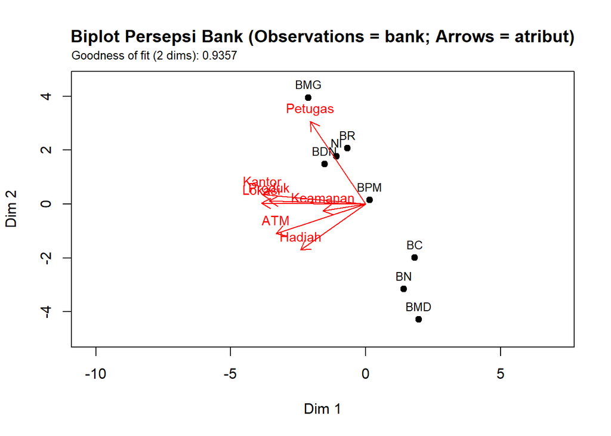

```r
# 11) Plot biplot (Gabriel-style)
# Atur batas plot sehingga titik & panah proporsional
xlim <- range(c(G_star[,1], Ht_star[1,])) * 1.15
ylim <- range(c(G_star[,2], Ht_star[2,])) * 1.15

plot(G_star, pch = 19, xlab = "Dim 1", ylab = "Dim 2",
     main = "Biplot Persepsi Bank (Observations = bank; Arrows = atribut)",
     xlim = xlim, ylim = ylim, asp = 1)
text(G_star, labels = rownames(G_star), pos = 3, cex = 0.8)

# skalakan panah agar enak dilihat (tidak mengubah arah/sudut)
arrow_scalef <- 0.9 * max(abs(c(G_star))) / max(abs(Ht_star))
Ht_plot <- Ht_star * arrow_scalef

arrows(0, 0, Ht_plot[1, ], Ht_plot[2, ], length = 0.12, col = "red", lwd = 1.2)
text(Ht_plot[1, ], Ht_plot[2, ], labels = colnames(Xc), col = "red", pos = 3, cex = 0.9)

mtext(paste0("Goodness of fit (2 dims): ", round(rho2,4)), side = 3, line = 0.5, at = par("usr")[1], adj = 0, cex = 0.8)
```

## Interpretasi Hasil

Hasil biplot menunjukkan bagaimana setiap bank dipersepsikan berdasarkan tujuh atribut layanan. Dua dimensi pertama sudah mampu menjelaskan sekitar 93 persen keragaman data, sehingga plot ini cukup akurat untuk menggambarkan hubungan antar bank dan atribut.

Atribut seperti lokasi, fasilitas kantor, keamanan, ATM, dan hadiah memiliki arah yang relatif sama. Bank-bank yang berada dekat dengan arah panah-panah ini dianggap unggul pada atribut tersebut. Dalam hal ini tidak ada bank yang benar-benar kuat pada arah tersebut, sehingga dapat disimpulkan bahwa perbedaan antar bank pada atribut fasilitas, keamanan, dan hadiah relatif kecil. Atribut produk dan kantor memiliki vektor panjang pada Dimensi 1, menandakan kedua atribut tersebut merupakan pembeda utama antara bank yang berada jauh di kanan dan bank yang berada lebih ke kiri.